# examples_0526

Consider the [L system](https://en.wikipedia.org/wiki/L-system) defined by the following start and replacement rules:

- Start = T
- Rules:
  - E → RRM
  - M → RRRR
  - R → TEM
  - T → RME

After 2 iterations, what string is developed?

- T
- RME
- TEMRRRRRRM

TEMRRRRRRM

Consider the [L system](https://en.wikipedia.org/wiki/L-system) defined by the following start and replacement rules:

- Start = Z
- Rules:
  - O → UO
  - U → OZZ
  - Z → ZZU

After 2 iterations, what string is developed?

- Z
- ZZU
- ZZUZZUOZZ

ZZUZZUOZZ

Consider the [L system](https://en.wikipedia.org/wiki/L-system) defined by the following start and replacement rules:

- Start = P
- Rules:
  - A → XP
  - B → ABP
  - P → BA
  - X → PXX

After 2 iterations, what string is developed?

- P
- BA
- ABPXP

ABPXP

Consider the [L system](https://en.wikipedia.org/wiki/L-system) defined by the following start and replacement rules:

- Start = ZM
- Rules:
  - M → MS
  - S → ZS
  - Y → SSZ
  - Z → ZY

After 2 iterations, what string is developed?

- ZM
- ZYMS
- ZYSSZMSZS

ZYSSZMSZS

Consider the [L system](https://en.wikipedia.org/wiki/L-system) defined by the following start and replacement rules:

- Start = R
- Rules:
  - J → MYM
  - M → MR
  - R → MMYY
  - Y → YJ

After 2 iterations, what string is developed?

- R
- MMYY
- MRMRYJYJ

MRMRYJYJ

Consider the [L system](https://en.wikipedia.org/wiki/L-system) defined by the following start and replacement rules:

- Start = G
- Rules:
  - E → GIZE
  - G → EZ
  - I → ZE
  - Z → II

After 2 iterations, what string is developed?

- G
- EZ
- GIZEII

GIZEII

Consider the [L system](https://en.wikipedia.org/wiki/L-system) defined by the following start and replacement rules:

- Start = TQ
- Rules:
  - K → KT
  - Q → QKT
  - T → QK

After 2 iterations, what string is developed?

- TQ
- QKQKT
- QKTKTQKTKTQK

QKTKTQKTKTQK

Consider the [L system](https://en.wikipedia.org/wiki/L-system) defined by the following start and replacement rules:

- Start = L
- Rules:
  - L → SLU
  - S → SLS
  - U → LSSL

After 2 iterations, what string is developed?

- L
- SLU
- SLSSLULSSL

SLSSLULSSL

Consider the [L system](https://en.wikipedia.org/wiki/L-system) defined by the following start and replacement rules:

- Start = C
- Rules:
  - B → BB
  - C → CBCL
  - L → BC

After 2 iterations, what string is developed?

- C
- CBCL
- CBCLBBCBCLBC

CBCLBBCBCLBC

Consider the [L system](https://en.wikipedia.org/wiki/L-system) defined by the following start and replacement rules:

- Start = HH
- Rules:
  - H → KH
  - J → KHJJ
  - K → KJ

After 2 iterations, what string is developed?

- HH
- KHKH
- KJKHKJKH

KJKHKJKH

Consider the [L system](https://en.wikipedia.org/wiki/L-system) defined by the following start and replacement rules:

- Start = PH
- Rules:
  - H $\to$ RPPT
  - P $\to$ PTR
  - R $\to$ HT
  - T $\to$ HPHT

After 3 iterations, what string is developed? I'd recommend using [this tool](https://chadworley.github.io/Lsys_string_gen.html).

Consider the [L system](https://en.wikipedia.org/wiki/L-system) defined by the following start and replacement rules:

- Start = AMX
- Rules:
  - A $\to$ ZAXX
  - M $\to$ AMZ
  - X $\to$ ZZ
  - Z $\to$ ZZZ

After 3 iterations, what string is developed? I'd recommend using [this tool](https://chadworley.github.io/Lsys_string_gen.html).

Consider the [L system](https://en.wikipedia.org/wiki/L-system) defined by the following start and replacement rules:

- Start = KS
- Rules:
  - C $\to$ SS
  - K $\to$ KS
  - S $\to$ CKSK

After 3 iterations, what string is developed? I'd recommend using [this tool](https://chadworley.github.io/Lsys_string_gen.html).

Consider the [L system](https://en.wikipedia.org/wiki/L-system) defined by the following start and replacement rules:

- Start = R
- Rules:
  - H $\to$ RRS
  - R $\to$ HS
  - S $\to$ HRS

After 4 iterations, what string is developed? I'd recommend using [this tool](https://chadworley.github.io/Lsys_string_gen.html).

Consider the [L system](https://en.wikipedia.org/wiki/L-system) defined by the following start and replacement rules:

- Start = YBY
- Rules:
  - B $\to$ YFB
  - F $\to$ FYY
  - Y $\to$ BYB

After 3 iterations, what string is developed? I'd recommend using [this tool](https://chadworley.github.io/Lsys_string_gen.html).

Consider the [L system](https://en.wikipedia.org/wiki/L-system) defined by the following start and replacement rules:

- Start = XCG
- Rules:
  - C $\to$ CX
  - G $\to$ XC
  - X $\to$ XGX

After 3 iterations, what string is developed? I'd recommend using [this tool](https://chadworley.github.io/Lsys_string_gen.html).

Consider the [L system](https://en.wikipedia.org/wiki/L-system) defined by the following start and replacement rules:

- Start = P
- Rules:
  - H $\to$ PM
  - M $\to$ HPHH
  - P $\to$ MHMP

After 3 iterations, what string is developed? I'd recommend using [this tool](https://chadworley.github.io/Lsys_string_gen.html).

Consider the [L system](https://en.wikipedia.org/wiki/L-system) defined by the following start and replacement rules:

- Start = R
- Rules:
  - J $\to$ JL
  - L $\to$ LLJR
  - R $\to$ JL

After 4 iterations, what string is developed? I'd recommend using [this tool](https://chadworley.github.io/Lsys_string_gen.html).

Consider the [L system](https://en.wikipedia.org/wiki/L-system) defined by the following start and replacement rules:

- Start = L
- Rules:
  - L $\to$ WLWW
  - R $\to$ WWLW
  - W $\to$ WRLL

After 3 iterations, what string is developed? I'd recommend using [this tool](https://chadworley.github.io/Lsys_string_gen.html).

Consider the [L system](https://en.wikipedia.org/wiki/L-system) defined by the following start and replacement rules:

- Start = C
- Rules:
  - C $\to$ LMCL
  - L $\to$ LM
  - M $\to$ LR
  - R $\to$ LR

After 5 iterations, what string is developed? I'd recommend using [this tool](https://chadworley.github.io/Lsys_string_gen.html).

A turtle starts at the central red dot facing North. It uses the following commands:

- Character `F` means drag pen **Forward**
- Character `+` means turn 90° right (clockwise)
- Character `-` means turn 90° left (counterclockwise)
- Character `X` means hop forward without drawing
- Character `[` means save current position at top of pile
- Character `]` means teleport to saved position (use position at top of pile and remove that position from pile)

Use the following command string:

`F[-FFFF]FFFFFFFF+FFFFFF[+FF]FFF`

Which drawing is correct?

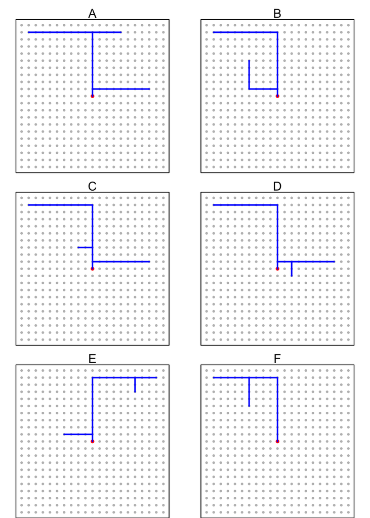

ABCDEF

The correct answer is E.

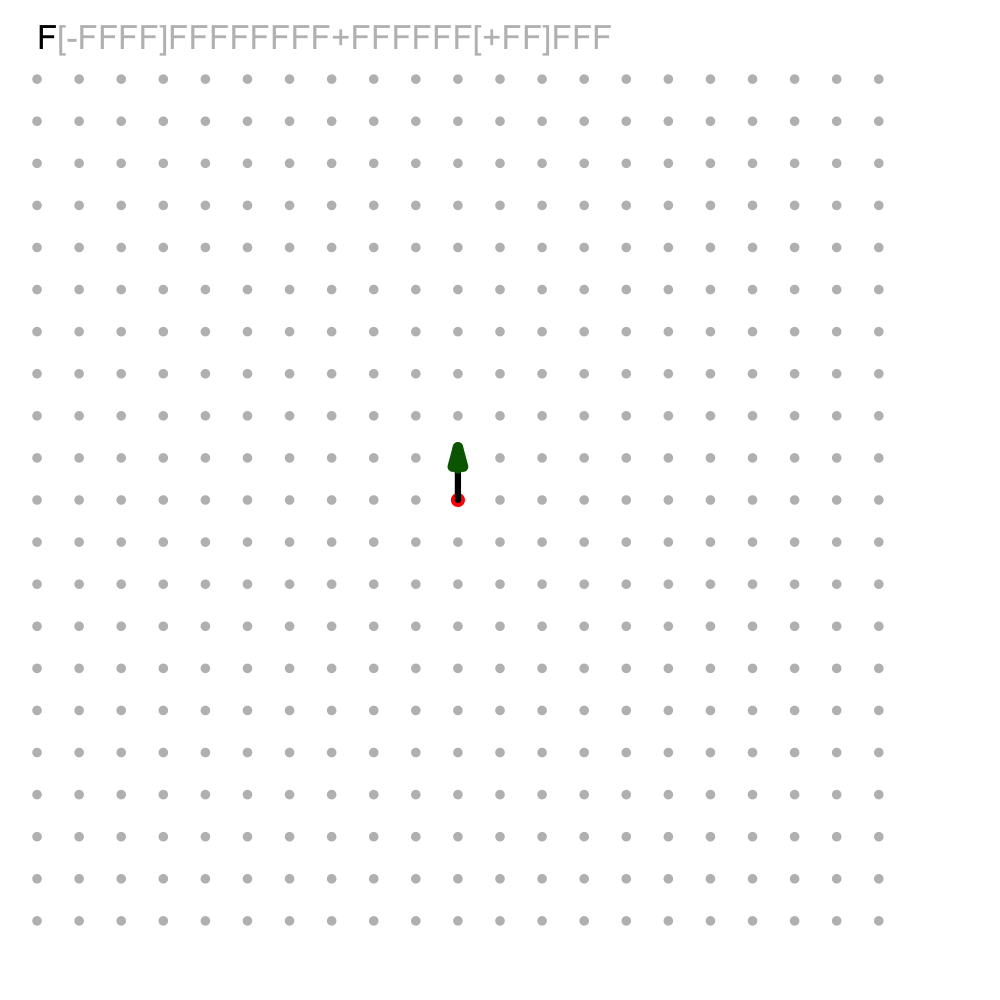

A turtle starts at the central red dot facing North. It uses the following commands:

- Character `F` means drag pen **Forward**
- Character `+` means turn 90° right (clockwise)
- Character `-` means turn 90° left (counterclockwise)
- Character `X` means hop forward without drawing
- Character `[` means save current position at top of pile
- Character `]` means teleport to saved position (use position at top of pile and remove that position from pile)

Use the following command string:

`F[-FFFFFFFF+FFFFFFFF]FFFF[-FFFF]FFFF-FFFFFFFFF`

Which drawing is correct?

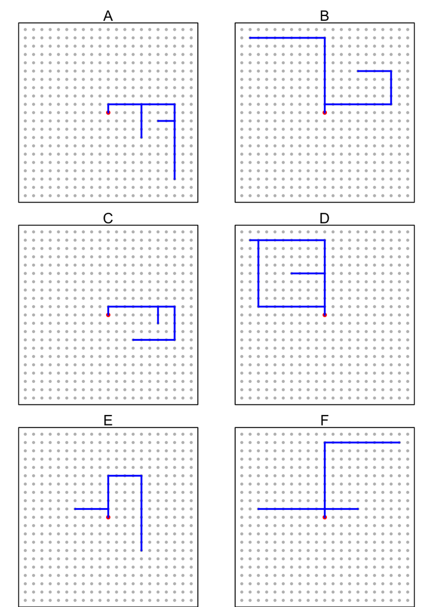

ABCDEF

The correct answer is D.

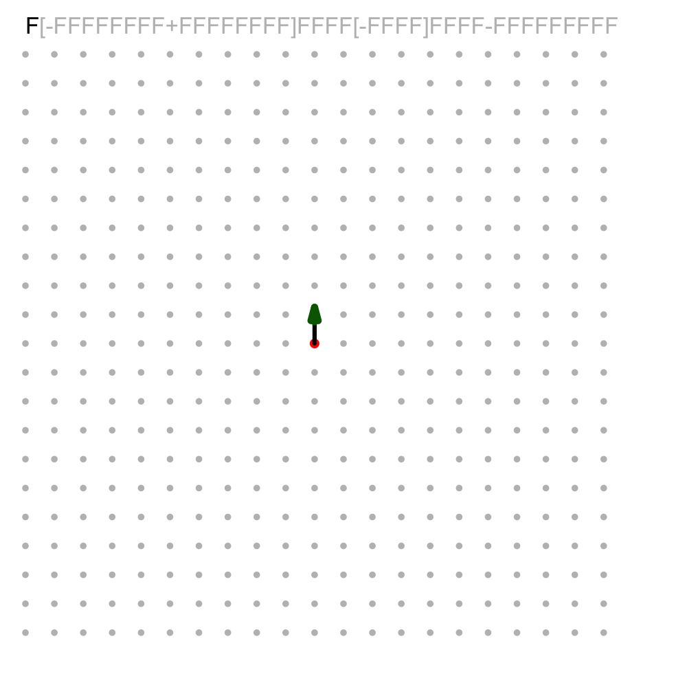

A turtle starts at the central red dot facing North. It uses the following commands:

- Character `F` means drag pen **Forward**
- Character `+` means turn 90° right (clockwise)
- Character `-` means turn 90° left (counterclockwise)
- Character `X` means hop forward without drawing
- Character `[` means save current position at top of pile
- Character `]` means teleport to saved position (use position at top of pile and remove that position from pile)

Use the following command string:

`F[-FF]FFFF+FFFF+FFFFFFFFF`

Which drawing is correct?

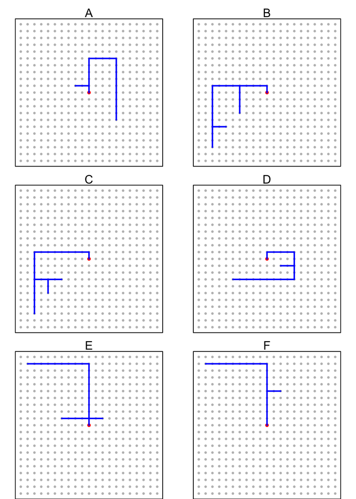

ABCDEF

The correct answer is A.

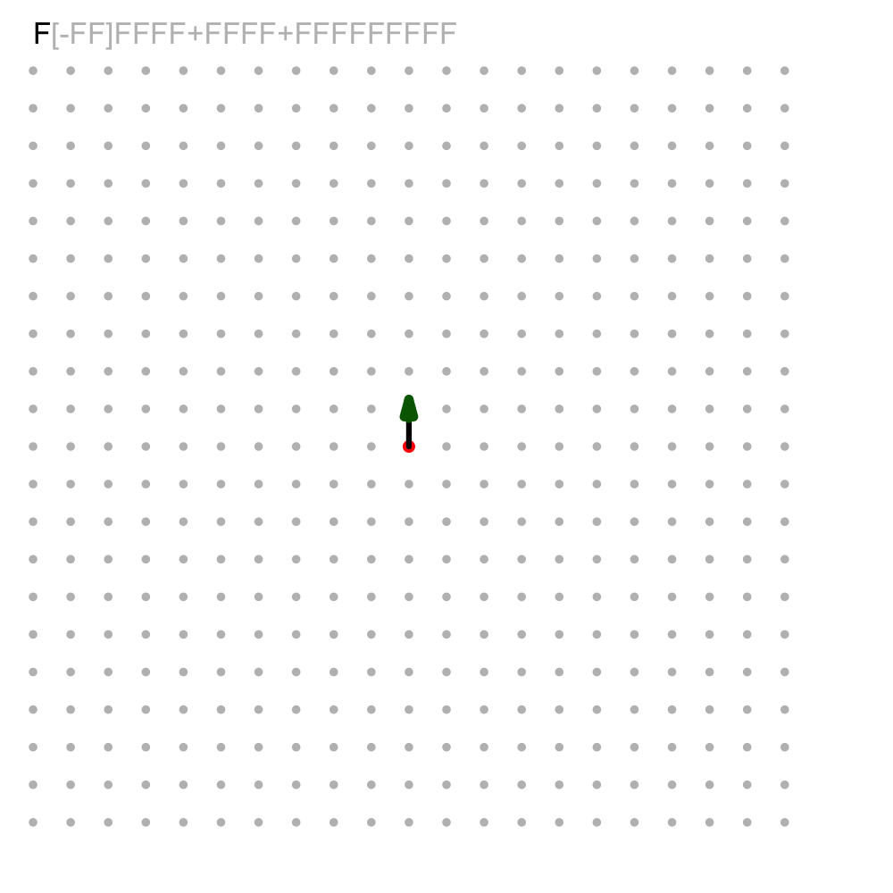

A turtle starts at the central red dot facing North. It uses the following commands:

- Character `F` means drag pen **Forward**
- Character `+` means turn 90° right (clockwise)
- Character `-` means turn 90° left (counterclockwise)
- Character `X` means hop forward without drawing
- Character `[` means save current position at top of pile
- Character `]` means teleport to saved position (use position at top of pile and remove that position from pile)

Use the following command string:

`F[+FF]FFFFFFFF+FFFFFFFFF`

Which drawing is correct?

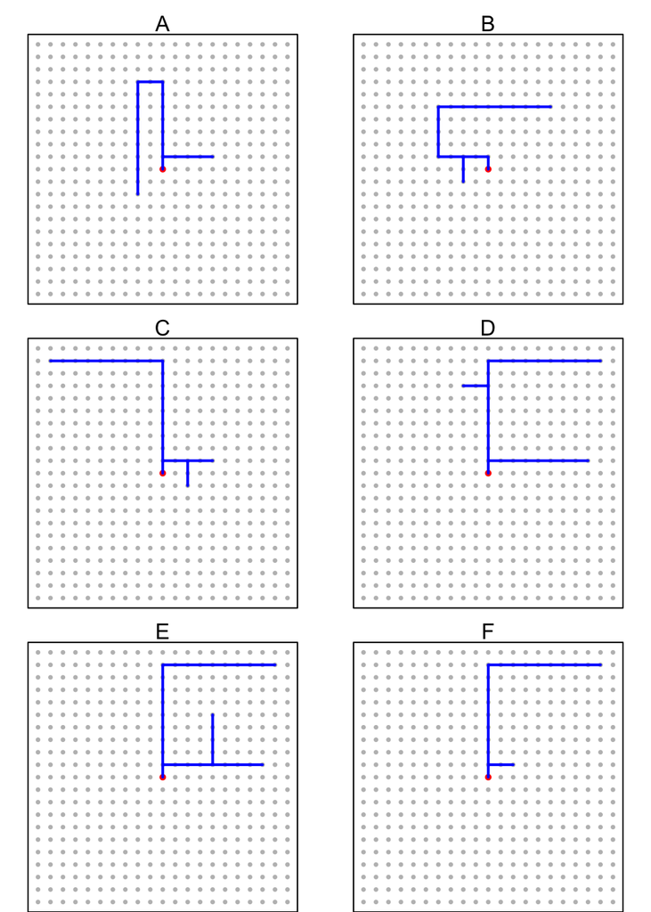

ABCDEF

The correct answer is F.

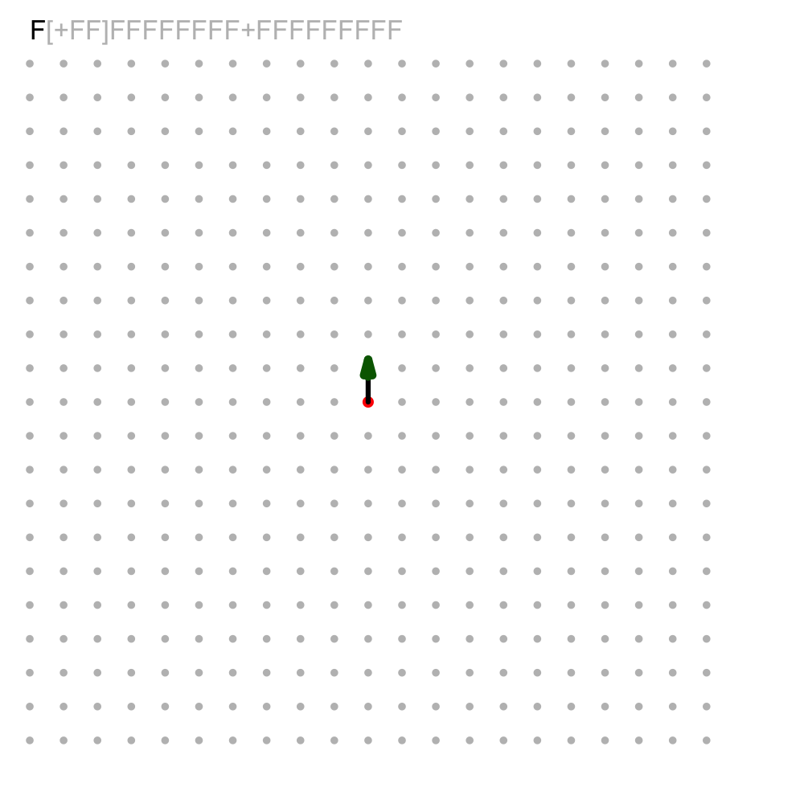

A turtle starts at the central red dot facing North. It uses the following commands:

- Character `F` means drag pen **Forward**
- Character `+` means turn 90° right (clockwise)
- Character `-` means turn 90° left (counterclockwise)
- Character `X` means hop forward without drawing
- Character `[` means save current position at top of pile
- Character `]` means teleport to saved position (use position at top of pile and remove that position from pile)

Use the following command string:

`F[+FFFFFFFF]-FFFFFFFF-FFFFFFFFF`

Which drawing is correct?

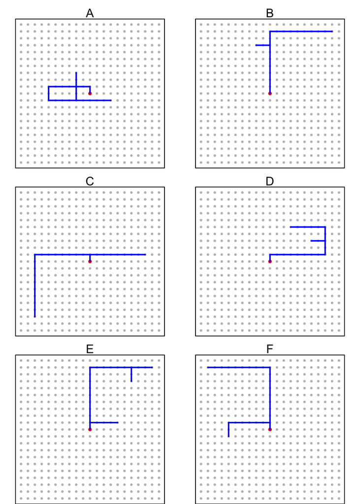

ABCDEF

The correct answer is C.

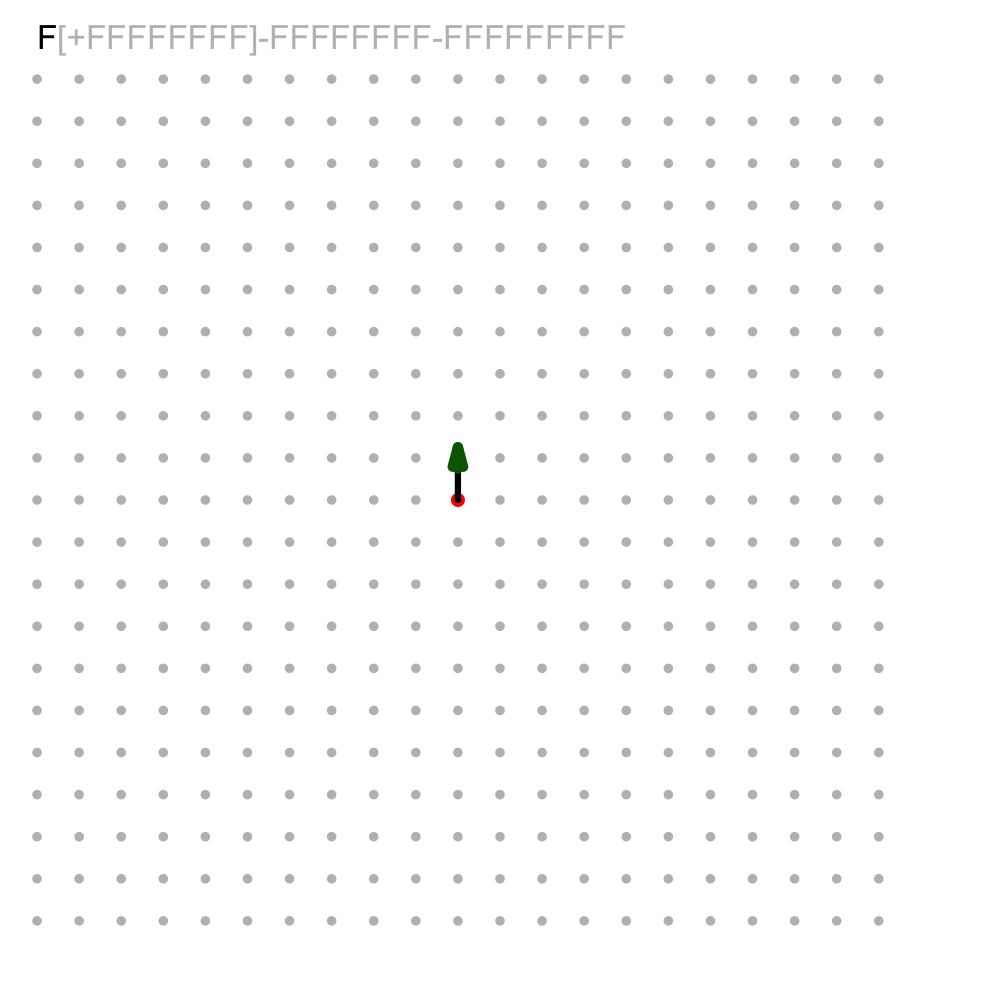

A turtle starts at the central red dot facing North. It uses the following commands:

- Character `F` means drag pen **Forward**
- Character `+` means turn 90° right (clockwise)
- Character `-` means turn 90° left (counterclockwise)
- Character `X` means hop forward without drawing
- Character `[` means save current position at top of pile
- Character `]` means teleport to saved position (use position at top of pile and remove that position from pile)

Use the following command string:

`F-FFFF+FFFF+FF[+FF]FFFFFFF`

Which drawing is correct?

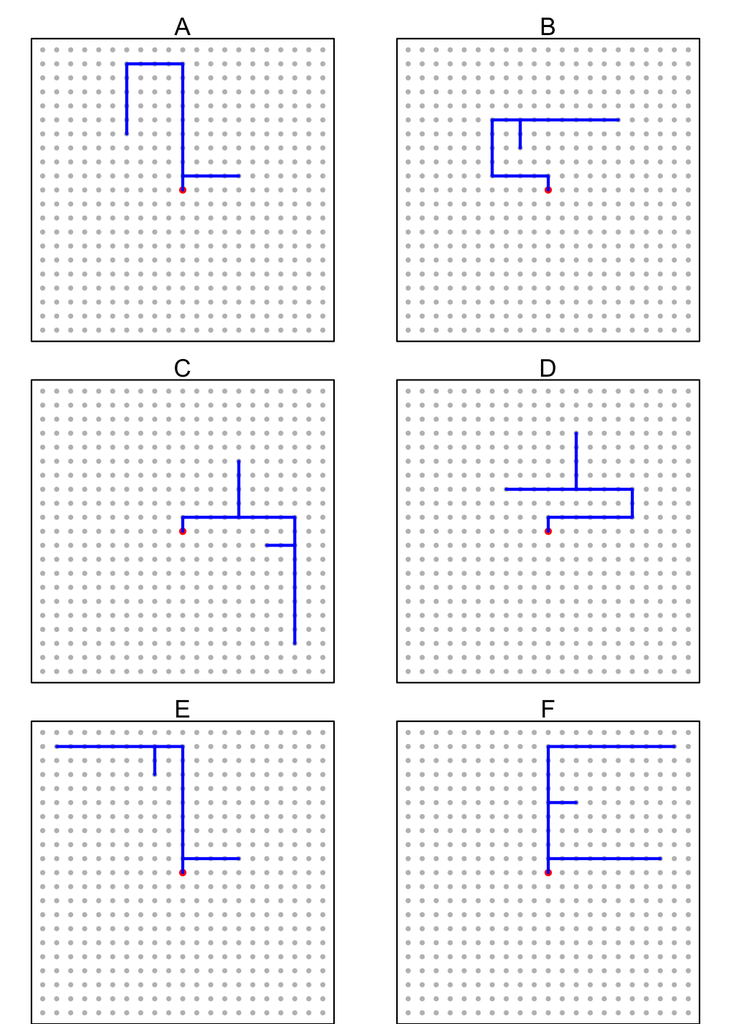

ABCDEF

The correct answer is B.

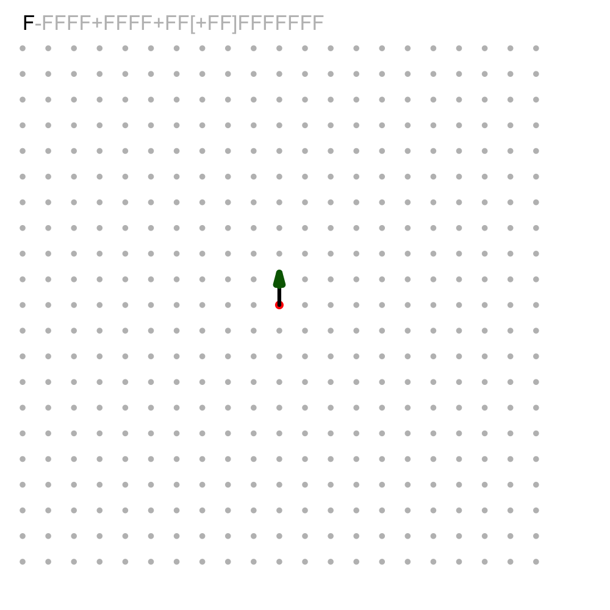

A turtle starts at the central red dot facing North. It uses the following commands:

- Character `F` means drag pen **Forward**
- Character `+` means turn 90° right (clockwise)
- Character `-` means turn 90° left (counterclockwise)
- Character `X` means hop forward without drawing
- Character `[` means save current position at top of pile
- Character `]` means teleport to saved position (use position at top of pile and remove that position from pile)

Use the following command string:

`F[+FFFF]FFFFFFFF-FFFFFFFFF`

Which drawing is correct?

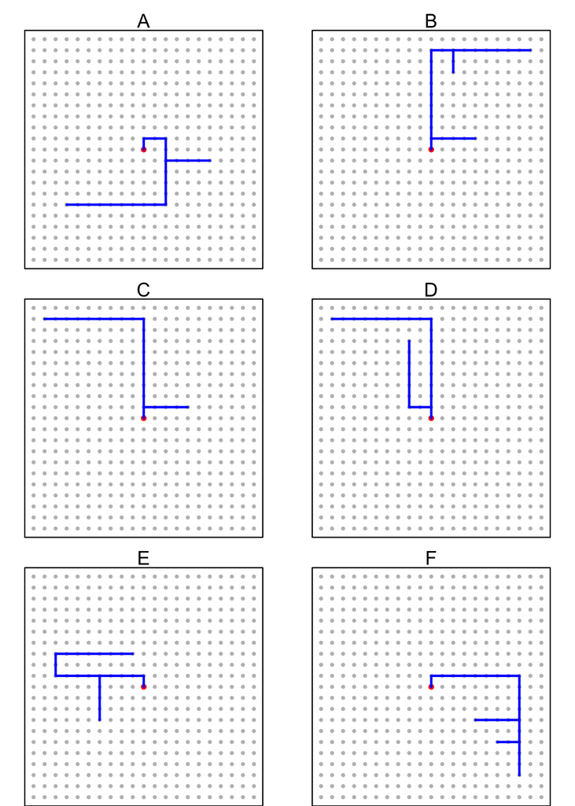

ABCDEF

The correct answer is C.

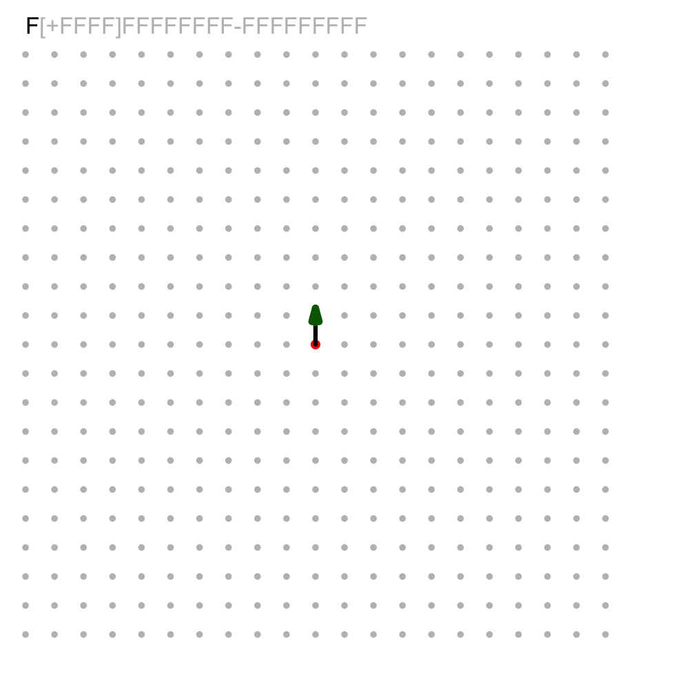

A turtle starts at the central red dot facing North. It uses the following commands:

- Character `F` means drag pen **Forward**
- Character `+` means turn 90° right (clockwise)
- Character `-` means turn 90° left (counterclockwise)
- Character `X` means hop forward without drawing
- Character `[` means save current position at top of pile
- Character `]` means teleport to saved position (use position at top of pile and remove that position from pile)

Use the following command string:

`F[-FFFF[+FF]FFFF-FFFFFFFF]FFFFFFFF+FFFFFFFFF`

Which drawing is correct?

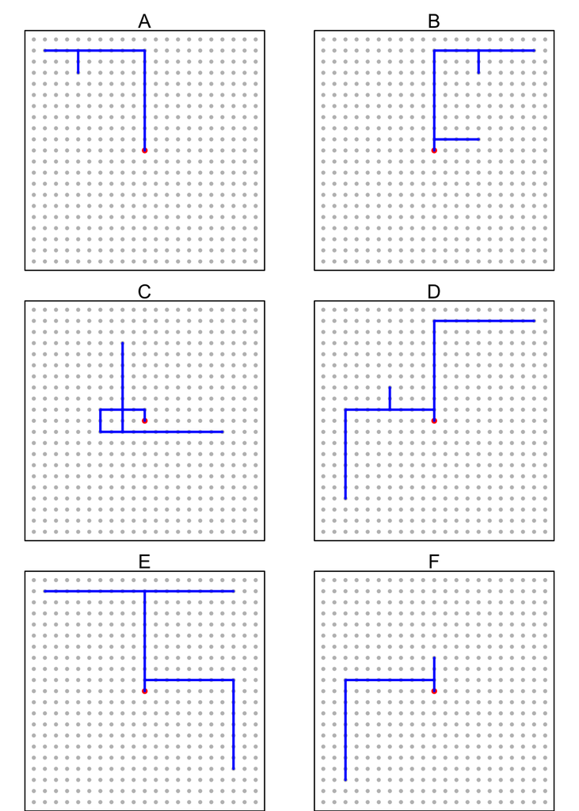

ABCDEF

The correct answer is D.

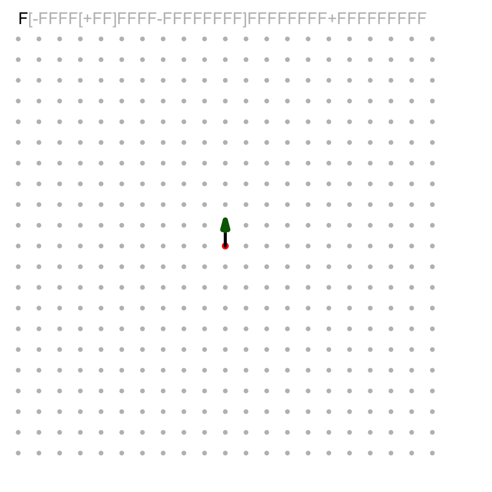

A turtle starts at the central red dot facing North. It uses the following commands:

- Character `F` means drag pen **Forward**
- Character `+` means turn 90° right (clockwise)
- Character `-` means turn 90° left (counterclockwise)
- Character `X` means hop forward without drawing
- Character `[` means save current position at top of pile
- Character `]` means teleport to saved position (use position at top of pile and remove that position from pile)

Use the following command string:

`F-FF+FFFFFF+FFFF[+FFFF]FFFFF`

Which drawing is correct?

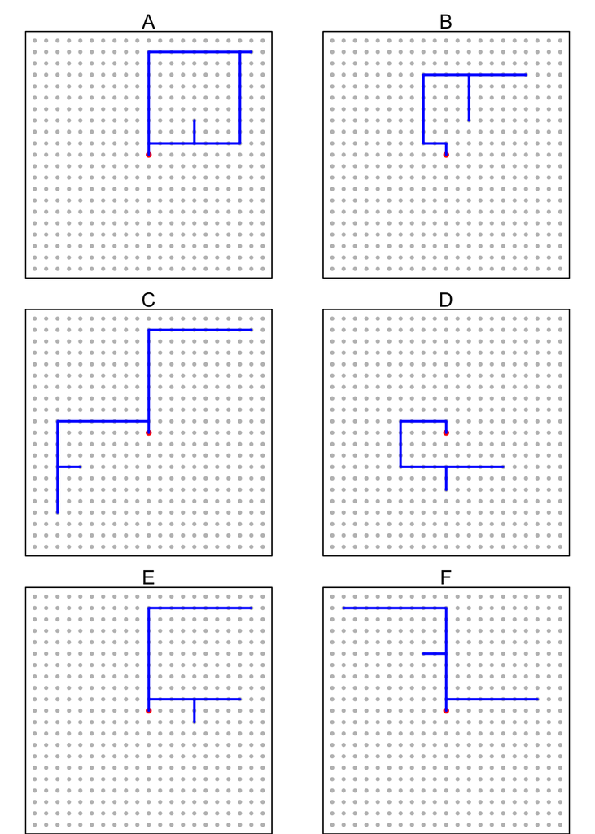

ABCDEF

The correct answer is B.

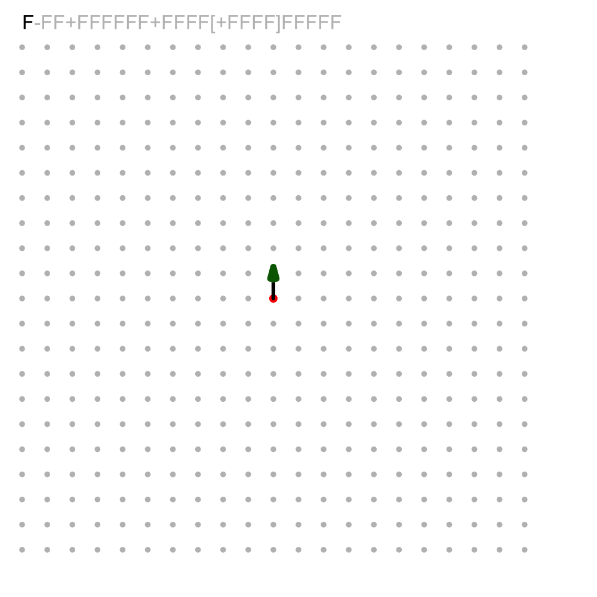

A turtle starts at the central red dot facing North. It uses the following commands:

- Character `F` means drag pen **Forward**
- Character `+` means turn 90° right (clockwise)
- Character `-` means turn 90° left (counterclockwise)
- Character `X` means hop forward without drawing
- Character `[` means save current position at top of pile
- Character `]` means teleport to saved position (use position at top of pile and remove that position from pile)

Use the following command string:

`F-FFFFFFFF+FF+FF[+FFFF]FFFFF`

Which drawing is correct?

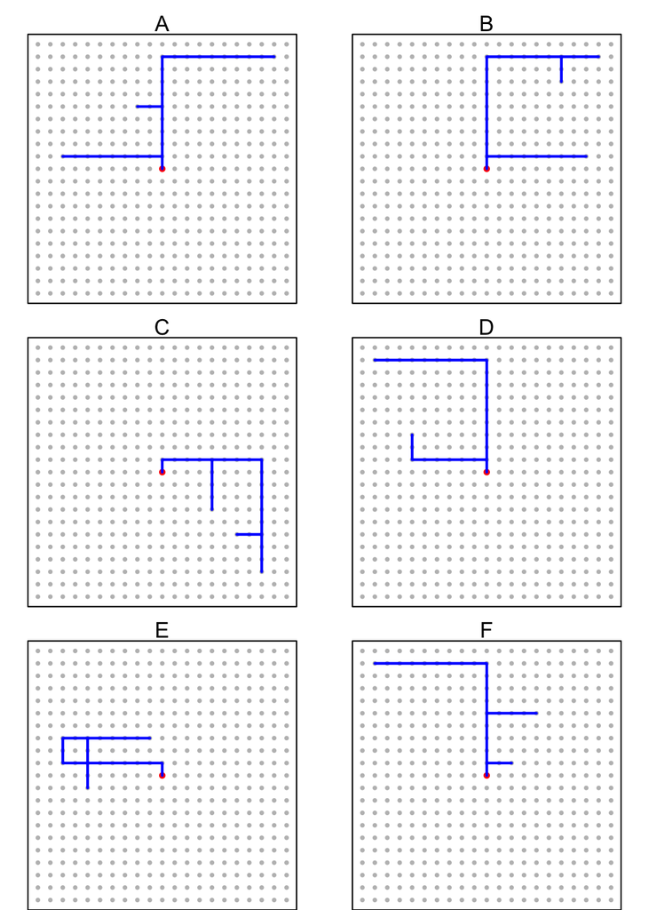

ABCDEF

The correct answer is E.

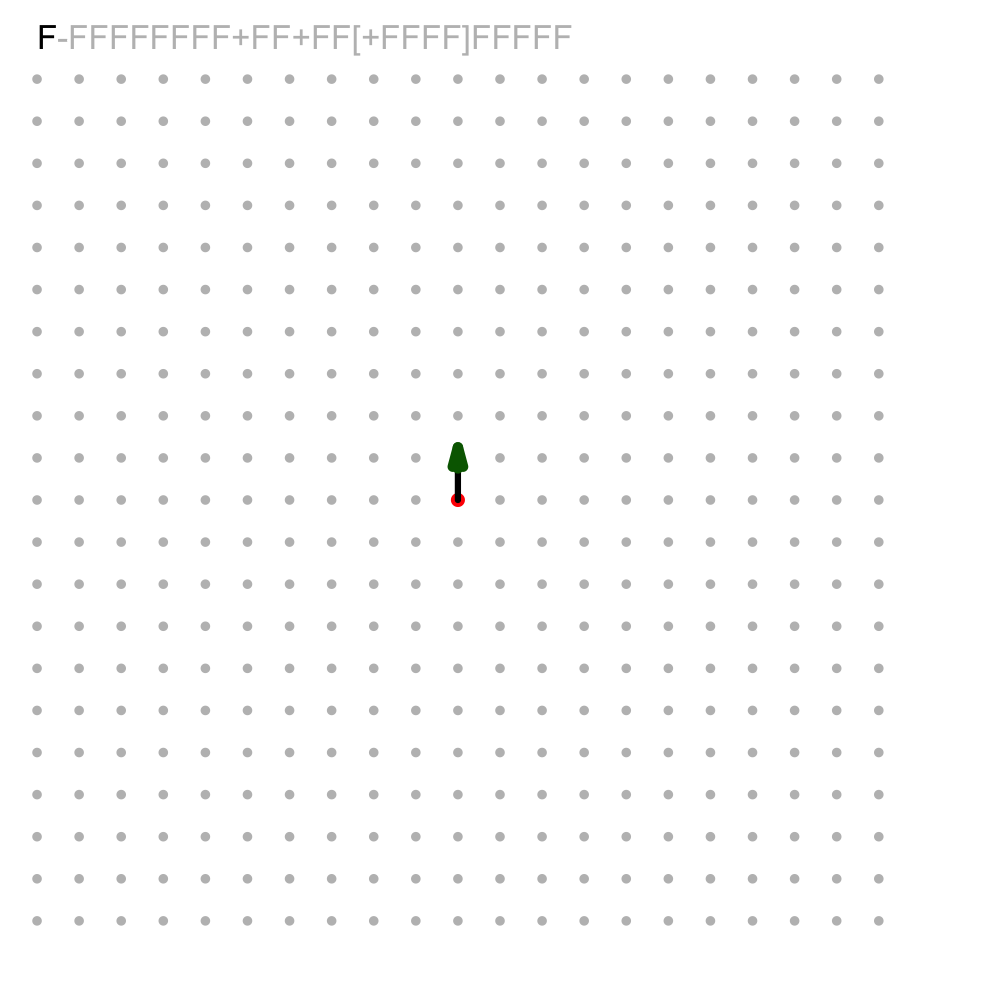

Consider the $L$-system (and turn angle) defined below:

- Start: `A`
- Rules:  
  `A > A[+A][-A]B`  
  `B > A[--B][++B]B`
- Number of recursions (number of iterations):
  - 6
- Turn angle
  - 108°

Please use [this online tool](https://artockthedino.github.io/lsys.html) to generate the pattern using turtle graphics. Choose the matching pattern. (The initial angle should be $270$ degrees to match the orientation.)

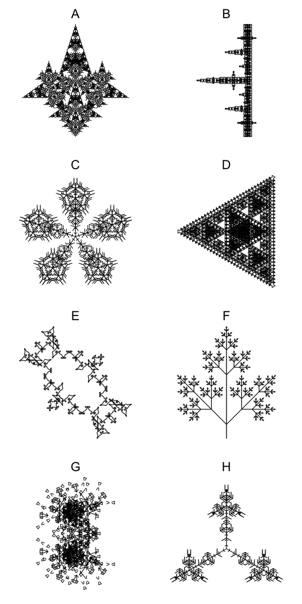

ABCDEFGH

The correct pattern is pattern A.

1. Use the first link: https://artockthedino.github.io/lsys.html
2. Copy/paste the `Axiom`, `Rules`, `Iterations`, and `Turn angle`.
3. Click `Generate Pattern`
4. Back to the quiz, select the matching pattern.

In case you're interested in the parameters of the other patterns shown:

## Pattern A

- Start: `A`
- Rules:  
  `A > A[+A][-A]B`  
  `B > A[--B][++B]B`
- Number of recursions (number of iterations):
  - 6
- Angle
  - 108

## Pattern B

- Start: `A`
- Rules:  
  `A > B-ABA-B`  
  `B > A+B+A`
- Number of recursions (number of iterations):
  - 6
- Angle
  - 90

## Pattern C

- Start: `[A]+[A]+[A]+[A]+[A]`
- Rules:  
  `A > AA[-B][+B]B`  
  `B > [-ABC][+ABC]`  
  `C > A[-CB][+CB]`
- Number of recursions (number of iterations):
  - 4
- Angle
  - 72

## Pattern D

- Start: `AAA`
- Rules:  
  `A > A++B-C-B++A`  
  `B > B--A+C+A--B`  
  `C > CC`
- Number of recursions (number of iterations):
  - 6
- Angle
  - 60

## Pattern E

- Start: `BABA`
- Rules:  
  `A > +BA+A-ABBA-A+AB+`  
  `B > +BBA-B--B-ABB+`
- Number of recursions (number of iterations):
  - 3
- Angle
  - 45

## Pattern F

- Start: `A`
- Rules:  
  `A > C[+CA][CCCA][-CA]`  
  `C > CC`
- Number of recursions (number of iterations):
  - 6
- Angle
  - 45

## Pattern G

- Start: `A`
- Rules:  
  `A > AXB+C+BXA`  
  `B > C--BAB--C`  
  `C > B+D-A-D+B`  
  `X > XX`  
  `D > DD`
- Number of recursions (number of iterations):
  - 5
- Angle
  - 108

## Pattern H

- Start: `[A]+[A]+[A]`
- Rules:  
  `A > AA[-B][+B]B`  
  `B > [-ABC][+ABC]`  
  `C > A[-CB][+CB]`
- Number of recursions (number of iterations):
  - 4
- Angle
  - 120

Consider the $L$-system (and turn angle) defined below:

- Start: `AA`
- Rules:  
  `A > +B-AAA-B+`  
  `B > -A+BBB+A-`
- Number of recursions (number of iterations):
  - 5
- Turn angle
  - 108°

Please use [this online tool](https://artockthedino.github.io/lsys.html) to generate the pattern using turtle graphics. Choose the matching pattern. (The initial angle should be $270$ degrees to match the orientation.)

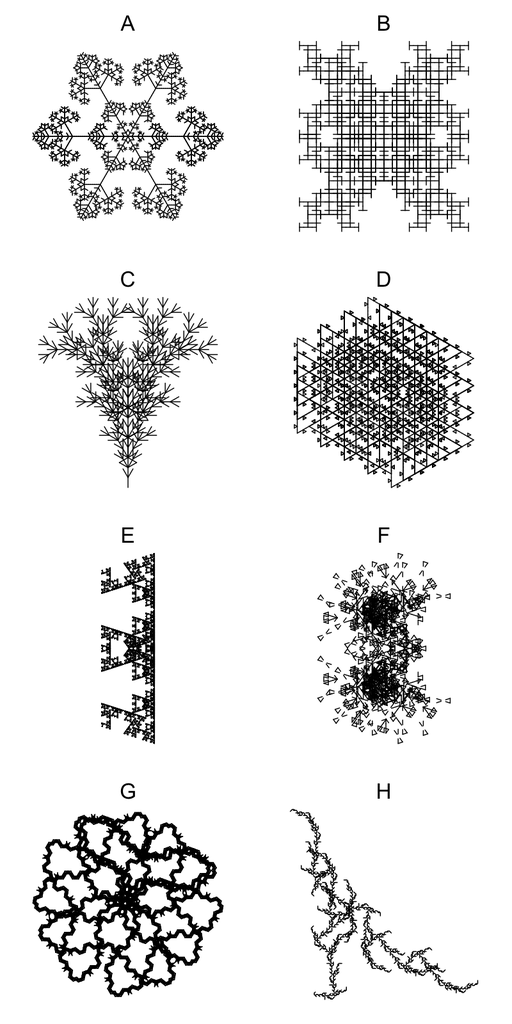

ABCDEFGH

The correct pattern is pattern E.

1. Use the first link: https://artockthedino.github.io/lsys.html
2. Copy/paste the `Axiom`, `Rules`, `Iterations`, and `Turn angle`.
3. Click `Generate Pattern`
4. Back to the quiz, select the matching pattern.

In case you're interested in the parameters of the other patterns shown:

## Pattern A

- Start: `A------A`
- Rules:  
  `A > [---B][-B][+B][+++B]`  
  `B > BD[++DA][--DA]B`  
  `D > DD`
- Number of recursions (number of iterations):
  - 5
- Angle
  - 30

## Pattern B

- Start: `A++A`
- Rules:  
  `A > AB[-A][+A]`  
  `B > A`
- Number of recursions (number of iterations):
  - 6
- Angle
  - 90

## Pattern C

- Start: `A`
- Rules:  
  `A > A[+A][-A]B`  
  `B > [--B][++B]A`
- Number of recursions (number of iterations):
  - 5
- Angle
  - 30

## Pattern D

- Start: `A`
- Rules:  
  `A > +BA-A--A--A-AB+`  
  `B > -AB+B++B++B+BA-`
- Number of recursions (number of iterations):
  - 5
- Angle
  - 120

## Pattern E

- Start: `AA`
- Rules:  
  `A > +B-AAA-B+`  
  `B > -A+BBB+A-`
- Number of recursions (number of iterations):
  - 5
- Angle
  - 108

## Pattern F

- Start: `A`
- Rules:  
  `A > AXB+C+BXA`  
  `B > C--BAB--C`  
  `C > B+D-A-D+B`  
  `X > XX`  
  `D > DD`
- Number of recursions (number of iterations):
  - 5
- Angle
  - 108

## Pattern G

- Start: `A`
- Rules:  
  `A > +++BA----ABA----AB+++`  
  `B > ---AB++++BAB++++BA---`
- Number of recursions (number of iterations):
  - 5
- Angle
  - 50

## Pattern H

- Start: `A++++A`
- Rules:  
  `A > +A-B-B[B]`  
  `B > -B+A+A[A]`
- Number of recursions (number of iterations):
  - 5
- Angle
  - 45

Consider the $L$-system (and turn angle) defined below:

- Start: `A`
- Rules:  
  `A > +B-AAA-B+`  
  `B > -A+BBB+A-`
- Number of recursions (number of iterations):
  - 5
- Turn angle
  - 120°

Please use [this online tool](https://artockthedino.github.io/lsys.html) to generate the pattern using turtle graphics. Choose the matching pattern. (The initial angle should be $270$ degrees to match the orientation.)

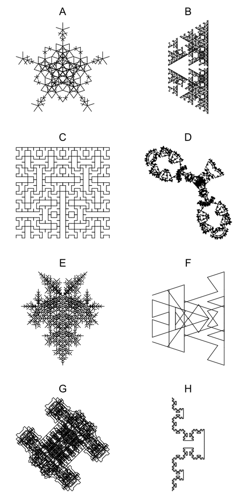

ABCDEFGH

The correct pattern is pattern B.

1. Use the first link: https://artockthedino.github.io/lsys.html
2. Copy/paste the `Axiom`, `Rules`, `Iterations`, and `Turn angle`.
3. Click `Generate Pattern`
4. Back to the quiz, select the matching pattern.

In case you're interested in the parameters of the other patterns shown:

## Pattern A

- Start: `A`
- Rules:  
  `A > [-AAB][--AAB][+AAB][++AAB]AAB`  
  `B > [-C][+C][--C][++C]CA`  
  `C > CC`
- Number of recursions (number of iterations):
  - 3
- Angle
  - 72

## Pattern B

- Start: `A`
- Rules:  
  `A > +B-AAA-B+`  
  `B > -A+BBB+A-`
- Number of recursions (number of iterations):
  - 5
- Angle
  - 120

## Pattern C

- Start: `-A`
- Rules:  
  `A > +B-AA-B+`  
  `B > -A+BB+A-`
- Number of recursions (number of iterations):
  - 5
- Angle
  - 90

## Pattern D

- Start: `BB`
- Rules:  
  `A > +BA+A-ABA-A+AB+`  
  `B > +BBA-B--B-ABB+`
- Number of recursions (number of iterations):
  - 4
- Angle
  - 69

## Pattern E

- Start: `A`
- Rules:  
  `A > A[+A][-A]A[+B][-B]`  
  `B > A[----B][++++B]B`
- Number of recursions (number of iterations):
  - 5
- Angle
  - 45

## Pattern F

- Start: `A`
- Rules:  
  `A > +B-AA-B+`  
  `B > -A+BB+A-`
- Number of recursions (number of iterations):
  - 3
- Angle
  - 108

## Pattern G

- Start: `A--A`
- Rules:  
  `A > +B++ACA++B+`  
  `B > -A--BCB--A-`  
  `C > C+ABA+C`
- Number of recursions (number of iterations):
  - 5
- Angle
  - 45

## Pattern H

- Start: `-A`
- Rules:  
  `A > A++B-C-B++A`  
  `B > B--A+C+A--B`  
  `C > CCC`
- Number of recursions (number of iterations):
  - 5
- Angle
  - 45

Consider the $L$-system (and turn angle) defined below:

- Start: `A`
- Rules:  
  `A > +BA-ACA-AB+`  
  `B > -AB+BCB+BA-`  
  `C > CCC`
- Number of recursions (number of iterations):
  - 5
- Turn angle
  - 90°

Please use [this online tool](https://artockthedino.github.io/lsys.html) to generate the pattern using turtle graphics. Choose the matching pattern. (The initial angle should be $270$ degrees to match the orientation.)

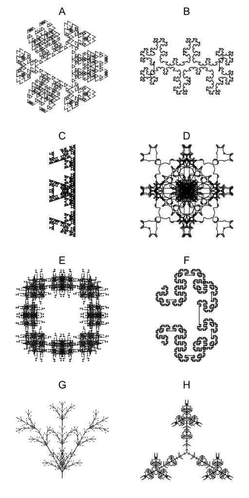

ABCDEFGH

The correct pattern is pattern F.

1. Use the first link: https://artockthedino.github.io/lsys.html
2. Copy/paste the `Axiom`, `Rules`, `Iterations`, and `Turn angle`.
3. Click `Generate Pattern`
4. Back to the quiz, select the matching pattern.

In case you're interested in the parameters of the other patterns shown:

## Pattern A

- Start: `A-A-A`
- Rules:  
  `A > +B-A+X+A-B+`  
  `B > -BA+BAXAB+AB-`  
  `X > XX`
- Number of recursions (number of iterations):
  - 4
- Angle
  - 120

## Pattern B

- Start: `A++A`
- Rules:  
  `A > +BA-ACA-BA+`  
  `B > -AB+CBABC+BA-`  
  `C > CCC`
- Number of recursions (number of iterations):
  - 4
- Angle
  - 90

## Pattern C

- Start: `AA`
- Rules:  
  `A > +B-AAA-B+`  
  `B > -A+BBB+A-`
- Number of recursions (number of iterations):
  - 5
- Angle
  - 108

## Pattern D

- Start: `A++A++A++A`
- Rules:  
  `A > +B-CAC-B+`  
  `B > -A++BB++A-`  
  `C > CC`
- Number of recursions (number of iterations):
  - 6
- Angle
  - 45

## Pattern E

- Start: `AAAA`
- Rules:  
  `A > +B-AXBACABXA-B+`  
  `B > -A+BXA+C+AXB+A-`  
  `C > C+C`  
  `X > XXX`
- Number of recursions (number of iterations):
  - 4
- Angle
  - 90

## Pattern F

- Start: `A`
- Rules:  
  `A > +BA-ACA-AB+`  
  `B > -AB+BCB+BA-`  
  `C > CCC`
- Number of recursions (number of iterations):
  - 5
- Angle
  - 90

## Pattern G

- Start: `X`
- Rules:  
  `F > FF`  
  `X > FF[+XFFX+XF][-XFFX-XF]FXXFX`
- Number of recursions (number of iterations):
  - 3
- Angle
  - 30

## Pattern H

- Start: `[A]+[A]+[A]`
- Rules:  
  `A > AA[-B][+B]B`  
  `B > [-ABC][+ABC]`  
  `C > A[-CB][+CB]`
- Number of recursions (number of iterations):
  - 4
- Angle
  - 120

Consider the $L$-system (and turn angle) defined below:

- Start: `-A`
- Rules:  
  `A > A++B-C-B++A`  
  `B > B--A+C+A--B`  
  `C > CCC`
- Number of recursions (number of iterations):
  - 5
- Turn angle
  - 45°

Please use [this online tool](https://artockthedino.github.io/lsys.html) to generate the pattern using turtle graphics. Choose the matching pattern. (The initial angle should be $270$ degrees to match the orientation.)

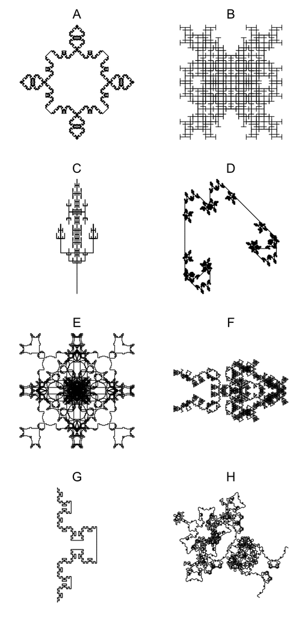

ABCDEFGH

The correct pattern is pattern G.

1. Use the first link: https://artockthedino.github.io/lsys.html
2. Copy/paste the `Axiom`, `Rules`, `Iterations`, and `Turn angle`.
3. Click `Generate Pattern`
4. Back to the quiz, select the matching pattern.

In case you're interested in the parameters of the other patterns shown:

## Pattern A

- Start: `AAAA`
- Rules:  
  `A > +B++ACA++B+`  
  `B > -A--BCB--A-`  
  `C > CC`
- Number of recursions (number of iterations):
  - 5
- Angle
  - 45

## Pattern B

- Start: `A++A`
- Rules:  
  `A > AB[-A][+A]`  
  `B > A`
- Number of recursions (number of iterations):
  - 6
- Angle
  - 90

## Pattern C

- Start: `A`
- Rules:  
  `A > CAA[--CAB][++CAB]`  
  `B > C[-CC-CA][+CC+CA]`  
  `C > CC`
- Number of recursions (number of iterations):
  - 5
- Angle
  - 90

## Pattern D

- Start: `A`
- Rules:  
  `A > +B-ACA-ACA-B+`  
  `B > -A+BCB+BCB+A-`  
  `C > CCC`
- Number of recursions (number of iterations):
  - 5
- Angle
  - 135

## Pattern E

- Start: `A++A++A++A`
- Rules:  
  `A > +B-CAC-B+`  
  `B > -A++BB++A-`  
  `C > CC`
- Number of recursions (number of iterations):
  - 6
- Angle
  - 45

## Pattern F

- Start: `A`
- Rules:  
  `A > C--ABA--C`  
  `B > B+C+B`  
  `C > -CA+AC-`
- Number of recursions (number of iterations):
  - 6
- Angle
  - 120

## Pattern G

- Start: `-A`
- Rules:  
  `A > A++B-C-B++A`  
  `B > B--A+C+A--B`  
  `C > CCC`
- Number of recursions (number of iterations):
  - 5
- Angle
  - 45

## Pattern H

- Start: `A`
- Rules:  
  `A > C--A++B++A--C`  
  `B > BA+C+AB`  
  `C > -B-CA+AC-B-`
- Number of recursions (number of iterations):
  - 5
- Angle
  - 60

Consider the $L$-system (and turn angle) defined below:

- Start: `A`
- Rules:  
  `A > C--ABA--C`  
  `B > B+C+B`  
  `C > -CA+AC-`
- Number of recursions (number of iterations):
  - 6
- Turn angle
  - 120°

Please use [this online tool](https://artockthedino.github.io/lsys.html) to generate the pattern using turtle graphics. Choose the matching pattern. (The initial angle should be $270$ degrees to match the orientation.)

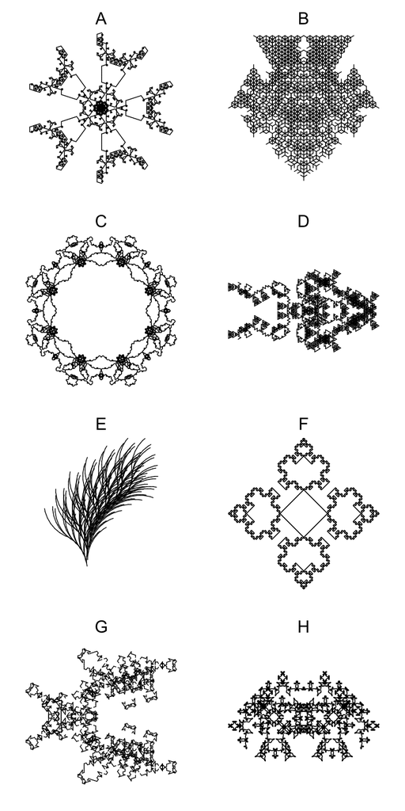

ABCDEFGH

The correct pattern is pattern D.

1. Use the first link: https://artockthedino.github.io/lsys.html
2. Copy/paste the `Axiom`, `Rules`, `Iterations`, and `Turn angle`.
3. Click `Generate Pattern`
4. Back to the quiz, select the matching pattern.

In case you're interested in the parameters of the other patterns shown:

## Pattern A

- Start: `AAAAA`
- Rules:  
  `A > B--A--B`  
  `B > A+BCB+A`  
  `C > CC`
- Number of recursions (number of iterations):
  - 5
- Angle
  - 72

## Pattern B

- Start: `A`
- Rules:  
  `A > A[+A][-A]A[+B][-B]`  
  `B > A[--B][++B]B`
- Number of recursions (number of iterations):
  - 5
- Angle
  - 60

## Pattern C

- Start: `AAAAAAAA`
- Rules:  
  `A > C--A++B++A--C`  
  `B > BA+C+AB`  
  `C > -B-CA+AC-B-`
- Number of recursions (number of iterations):
  - 4
- Angle
  - 45

## Pattern D

- Start: `A`
- Rules:  
  `A > C--ABA--C`  
  `B > B+C+B`  
  `C > -CA+AC-`
- Number of recursions (number of iterations):
  - 6
- Angle
  - 120

## Pattern E

- Start: `A`
- Rules:  
  `A > X[-B+BB+BB+BB+BB+BB+B]`  
  `X > XX`  
  `B > X[+A-AA-AA-AA-AA-AA-A]`
- Number of recursions (number of iterations):
  - 3
- Angle
  - 10

## Pattern F

- Start: `AAAA`
- Rules:  
  `A > A++B-C-B++A`  
  `B > B--A+C+A--B`  
  `C > CCC`
- Number of recursions (number of iterations):
  - 5
- Angle
  - 45

## Pattern G

- Start: `A`
- Rules:  
  `A > AXB+C+BXA`  
  `B > C--BAB--C`  
  `C > B+D-A-D+B`  
  `X > XX`  
  `D > DD`
- Number of recursions (number of iterations):
  - 5
- Angle
  - 72

## Pattern H

- Start: `BB`
- Rules:  
  `A > +BA+A-ABBA-A+AB+`  
  `B > +BBA-B--B-ABB+`
- Number of recursions (number of iterations):
  - 4
- Angle
  - 45

Consider the $L$-system (and turn angle) defined below:

- Start: `A`
- Rules:  
  `A > A[-DB][+DB]C`  
  `B > DC[++DA][--DA]B`  
  `C > [+++D][---D]A`  
  `D > DD`
- Number of recursions (number of iterations):
  - 6
- Turn angle
  - 40°

Please use [this online tool](https://artockthedino.github.io/lsys.html) to generate the pattern using turtle graphics. Choose the matching pattern. (The initial angle should be $270$ degrees to match the orientation.)

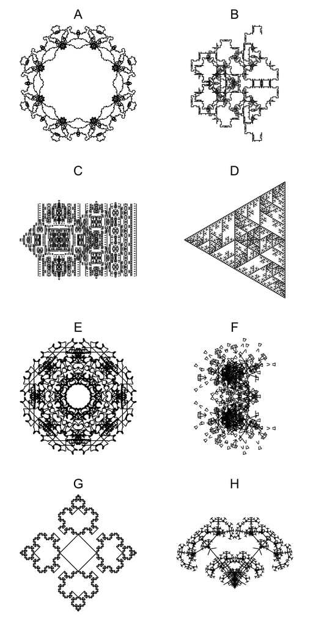

ABCDEFGH

The correct pattern is pattern H.

1. Use the first link: https://artockthedino.github.io/lsys.html
2. Copy/paste the `Axiom`, `Rules`, `Iterations`, and `Turn angle`.
3. Click `Generate Pattern`
4. Back to the quiz, select the matching pattern.

In case you're interested in the parameters of the other patterns shown:

## Pattern A

- Start: `AAAAAAAA`
- Rules:  
  `A > C--A++B++A--C`  
  `B > BA+C+AB`  
  `C > -B-CA+AC-B-`
- Number of recursions (number of iterations):
  - 4
- Angle
  - 45

## Pattern B

- Start: `A`
- Rules:  
  `A > +BA+A-ABA-A+AB+`  
  `B > +BA-B--B-AB+`
- Number of recursions (number of iterations):
  - 4
- Angle
  - 90

## Pattern C

- Start: `A`
- Rules:  
  `A > +BX-AA-XB+`  
  `B > -AXB+B+BXA-`  
  `X > XX`
- Number of recursions (number of iterations):
  - 6
- Angle
  - 90

## Pattern D

- Start: `A--A--A`
- Rules:  
  `A > A[-A]A`
- Number of recursions (number of iterations):
  - 6
- Angle
  - 60

## Pattern E

- Start: `A-A-A-A-A-A-A-A`
- Rules:  
  `A > +B-CAC-B+`  
  `B > -A++BB++A-`  
  `C > CC`
- Number of recursions (number of iterations):
  - 6
- Angle
  - 45

## Pattern F

- Start: `A`
- Rules:  
  `A > AXB+C+BXA`  
  `B > C--BAB--C`  
  `C > B+D-A-D+B`  
  `X > XX`  
  `D > DD`
- Number of recursions (number of iterations):
  - 5
- Angle
  - 108

## Pattern G

- Start: `AAAA`
- Rules:  
  `A > A++B-C-B++A`  
  `B > B--A+C+A--B`  
  `C > CCC`
- Number of recursions (number of iterations):
  - 5
- Angle
  - 45

## Pattern H

- Start: `A`
- Rules:  
  `A > A[-DB][+DB]C`  
  `B > DC[++DA][--DA]B`  
  `C > [+++D][---D]A`  
  `D > DD`
- Number of recursions (number of iterations):
  - 6
- Angle
  - 40

Consider the $L$-system (and turn angle) defined below:

- Start: `A`
- Rules:  
  `A > +BA--AA--AB+`  
  `B > -AB++BB++BA-`
- Number of recursions (number of iterations):
  - 5
- Turn angle
  - 30°

Please use [this online tool](https://artockthedino.github.io/lsys.html) to generate the pattern using turtle graphics. Choose the matching pattern. (The initial angle should be $270$ degrees to match the orientation.)

[figure not shown]

ABCDEFGH

The correct pattern is pattern B.

1. Use the first link: https://artockthedino.github.io/lsys.html
2. Copy/paste the `Axiom`, `Rules`, `Iterations`, and `Turn angle`.
3. Click `Generate Pattern`
4. Back to the quiz, select the matching pattern.

In case you're interested in the parameters of the other patterns shown:

## Pattern A

- Start: `[+A][-B]`
- Rules:  
  `A > [-CA-CB]A`  
  `B > [+CB+CA]B`  
  `C > CC`
- Number of recursions (number of iterations):
  - 6
- Angle
  - 120

## Pattern B

- Start: `A`
- Rules:  
  `A > +BA--AA--AB+`  
  `B > -AB++BB++BA-`
- Number of recursions (number of iterations):
  - 5
- Angle
  - 30

## Pattern C

- Start: `AA`
- Rules:  
  `A > A--ACB+C+BCA--A`  
  `B > BA+++C+++AB`  
  `C > -B--A+C+A--B-`
- Number of recursions (number of iterations):
  - 4
- Angle
  - 174

## Pattern D

- Start: `AAA`
- Rules:  
  `A > A++B-C-B++A`  
  `B > B--A+C+A--B`  
  `C > CC`
- Number of recursions (number of iterations):
  - 6
- Angle
  - 60

## Pattern E

- Start: `AAAAAA`
- Rules:  
  `A > +B-AXB---ACA---BXA-B+`  
  `B > -A++BXA+++C+++AXB++A-`  
  `C > CC+CC`  
  `X > ++BAX+C+XAB++`
- Number of recursions (number of iterations):
  - 3
- Angle
  - 60

## Pattern F

- Start: `A-A-A-A`
- Rules:  
  `A > +B-A-B+`  
  `B > -A++B+C+B++A-`  
  `C > CC`
- Number of recursions (number of iterations):
  - 6
- Angle
  - 90

## Pattern G

- Start: `B`
- Rules:  
  `A > [+DBC][-DBC][+++DBC]`  
  `B > [-BA][+BA]`  
  `C > AB`  
  `D > XX`  
  `X > XX`
- Number of recursions (number of iterations):
  - 6
- Angle
  - 120

## Pattern H

- Start: `A`
- Rules:  
  `A > B-A-B`  
  `B > A+B+A`
- Number of recursions (number of iterations):
  - 6
- Angle
  - 60

Consider the $L$-system (and turn angle) defined below:

- Start: `A++A`
- Rules:  
  `A > +B-CAC-B+`  
  `B > -A+BB+A-`  
  `C > CC`
- Number of recursions (number of iterations):
  - 6
- Turn angle
  - 90°

Please use [this online tool](https://artockthedino.github.io/lsys.html) to generate the pattern using turtle graphics. Choose the matching pattern. (The initial angle should be $270$ degrees to match the orientation.)

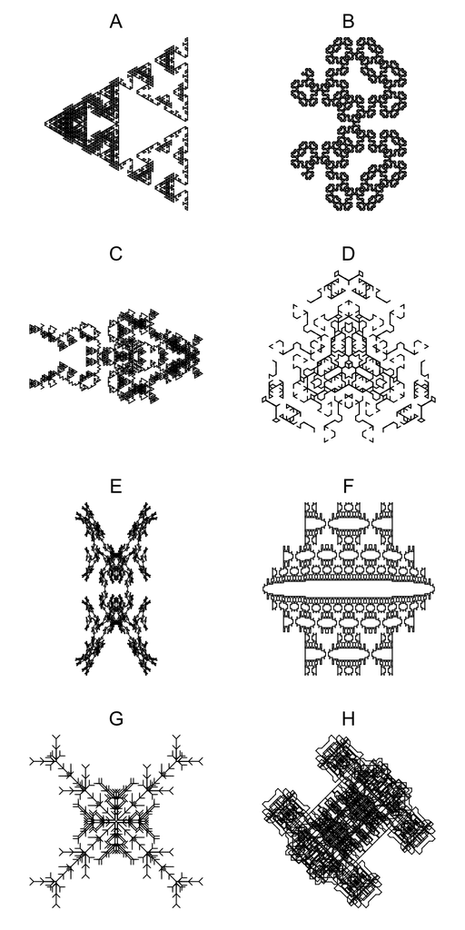

ABCDEFGH

The correct pattern is pattern F.

1. Use the first link: https://artockthedino.github.io/lsys.html
2. Copy/paste the `Axiom`, `Rules`, `Iterations`, and `Turn angle`.
3. Click `Generate Pattern`
4. Back to the quiz, select the matching pattern.

In case you're interested in the parameters of the other patterns shown:

## Pattern A

- Start: `A`
- Rules:  
  `A > B-ABA-B`  
  `B > A+B+A`
- Number of recursions (number of iterations):
  - 6
- Angle
  - 120

## Pattern B

- Start: `A`
- Rules:  
  `A > +BA-ABA-AB+`  
  `B > -AB+BAB+BA-`
- Number of recursions (number of iterations):
  - 5
- Angle
  - 90

## Pattern C

- Start: `A`
- Rules:  
  `A > C--ABA--C`  
  `B > B+C+B`  
  `C > -CA+AC-`
- Number of recursions (number of iterations):
  - 6
- Angle
  - 120

## Pattern D

- Start: `A+A+A+A+A+A`
- Rules:  
  `A > +B-AXB---ACA---BXA-B+`  
  `B > -A++BXA+C+AXB++A-`  
  `C > C+C`  
  `X > XXX`
- Number of recursions (number of iterations):
  - 3
- Angle
  - 60

## Pattern E

- Start: `A++++++A`
- Rules:  
  `A > +B-AXBXA-B+`  
  `B > -A+BXAXB+A-`  
  `X > XX`
- Number of recursions (number of iterations):
  - 5
- Angle
  - 150

## Pattern F

- Start: `A++A`
- Rules:  
  `A > +B-CAC-B+`  
  `B > -A+BB+A-`  
  `C > CC`
- Number of recursions (number of iterations):
  - 6
- Angle
  - 90

## Pattern G

- Start: `A++++A`
- Rules:  
  `A > [+BCC][-BCC]`  
  `B > B[-CA][+CA]`  
  `C > CCA`
- Number of recursions (number of iterations):
  - 5
- Angle
  - 45

## Pattern H

- Start: `A--A`
- Rules:  
  `A > +B++ACA++B+`  
  `B > -A--BCB--A-`  
  `C > C+ABA+C`
- Number of recursions (number of iterations):
  - 5
- Angle
  - 45

Consider the $L$-system (and turn angle) defined below:

- Start: `[+A][-B]`
- Rules:  
  `A > [-CA-CB]A`  
  `B > [+CB+CA]B`  
  `C > CC`
- Number of recursions (number of iterations):
  - 6
- Turn angle
  - 120°

Please use [this online tool](https://artockthedino.github.io/lsys.html) to generate the pattern using turtle graphics. Choose the matching pattern. (The initial angle should be $270$ degrees to match the orientation.)

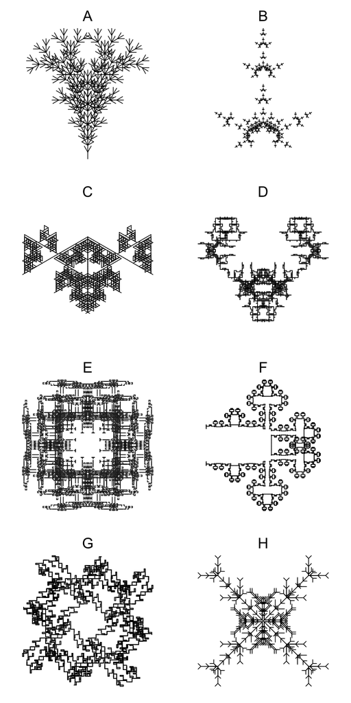

ABCDEFGH

The correct pattern is pattern C.

1. Use the first link: https://artockthedino.github.io/lsys.html
2. Copy/paste the `Axiom`, `Rules`, `Iterations`, and `Turn angle`.
3. Click `Generate Pattern`
4. Back to the quiz, select the matching pattern.

In case you're interested in the parameters of the other patterns shown:

## Pattern A

- Start: `A`
- Rules:  
  `A > A[+A][-A]B`  
  `B > [--B][++B]A`
- Number of recursions (number of iterations):
  - 5
- Angle
  - 30

## Pattern B

- Start: `A`
- Rules:  
  `A > X[-A][+A]AA`  
  `X > XX`
- Number of recursions (number of iterations):
  - 5
- Angle
  - 60

## Pattern C

- Start: `[+A][-B]`
- Rules:  
  `A > [-CA-CB]A`  
  `B > [+CB+CA]B`  
  `C > CC`
- Number of recursions (number of iterations):
  - 6
- Angle
  - 120

## Pattern D

- Start: `-A`
- Rules:  
  `A > +BA+A-ABA-A+AB+`  
  `B > +BBA-B--B-ABB+`
- Number of recursions (number of iterations):
  - 4
- Angle
  - 90

## Pattern E

- Start: `A+A+A+A`
- Rules:  
  `A > +B-AXBACABXA-B+`  
  `B > -A+BXA+C+AXB+A-`  
  `C > CC`  
  `X > XXX`
- Number of recursions (number of iterations):
  - 4
- Angle
  - 90

## Pattern F

- Start: `A`
- Rules:  
  `A > +BA+ACCA+AB+`  
  `B > -C+++BACCAB+++C-`  
  `C > CC`
- Number of recursions (number of iterations):
  - 5
- Angle
  - 90

## Pattern G

- Start: `A+A+A+A`
- Rules:  
  `A > C[++CB][--CB]`  
  `B > C-BAB+C`  
  `C > CAB`
- Number of recursions (number of iterations):
  - 6
- Angle
  - 90

## Pattern H

- Start: `A++++A`
- Rules:  
  `A > [+BCC][-BCC]`  
  `B > B[-CA][+CA]`  
  `C > CCA`
- Number of recursions (number of iterations):
  - 5
- Angle
  - 45